# ROS2

ROS 2 (Robot Operating System 2) is a set of software libraries and tools designed to help developers build robotic applications. It's a second-generation version of the original ROS, addressing many limitations from ROS 1 while introducing improvements in performance, security, and real-time capabilities.

## Installation of ROS2:

```python
sudo apt update && sudo apt install curl -y
sudo curl -sSL https://raw.githubusercontent.com/ros/rosdistro/master/ros.asc | sudo apt-key add -
sudo sh -c 'echo "deb [trusted=yes] http://packages.ros.org/ros2/ubuntu $(lsb_release -cs) main" > /etc/apt/sources.list.d/ros2-latest.list'
```

```python
sudo apt update
sudo apt install ros-humble-desktop
```

```python
source /opt/ros/humble/setup.bash
```

## Basics in ROS2:

#### 1. ROS2 Workspace

A workspace in ROS 2 is a directory where you organize and build your ROS 2 projects (packages).

##### Create the Workspace Directory

First, you need to create a directory that will serve as your workspace. Inside this directory, you will create a src folder to hold your packages.

```python
mkdir -p ~/ros2_ws/src
cd ~/ros2_ws
```

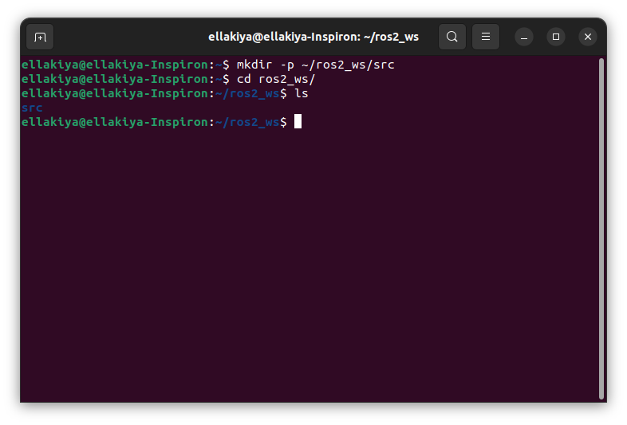

##### Initialize the Workspace

Before building anything, you need to ensure the workspace is initialized properly. The src directory should be empty for the initial setup, but it will contain your packages later.

```python
cd ~/ros2_ws
colcon build
```

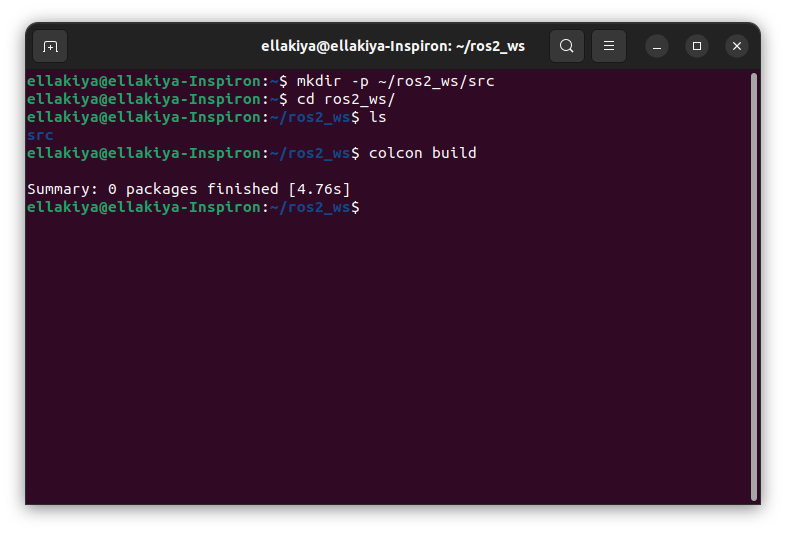

##### Source the Workspace

After building your workspace, you need to source it so that your environment knows about the packages in the workspace.

```python
source install/setup.bash
```

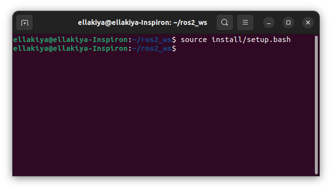

If you want to automatically source your workspace whenever you open a new terminal, you can add the above command to your .bashrc file:

```python
echo "source ~/ros2_ws/install/setup.bash" >> ~/.bashrc
source ~/.bashrc
```

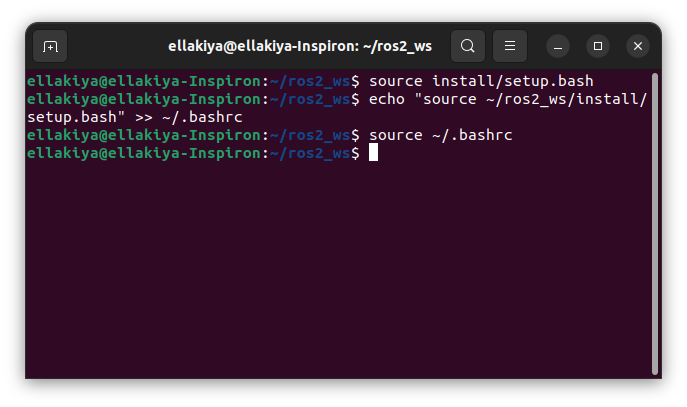